# Beispiel-Foliensatz

Gestaltungselemente des Formats rptu-revealjs

21.10.2026

## Bevor es losgeht

- Öffnen Sie RStudio und das Skript zur heutigen Sitzung
- Laden Sie das Paket ggplot2: `library(ggplot2)`

`{.vor-titel}` stellt diese Folie im Vortrag vor die Titelfolie, der Vortrag beginnt hier. `{.no-handout}` lässt sie im Handout weg.

## Heutige Themen

### Aufbau eines Foliensatzes

- Abschnitte, Folien und Zwischenüberschriften

### Gestaltungselemente

- Pausen, Kästen, Farben und Symbole

### R-Code und Output

- Grafiken, Markierungen im Output, Übungsfolgen

# Aufbau eines Foliensatzes

Abschnitte, Folien und Zwischenüberschriften

## Folien und Zwischenüberschriften

### Abschnitte

- `# Titel` erzeugt eine Abschnittsfolie, fortlaufend nummeriert (01, 02, …)
- `abschnitt-anzeige: true` im Kopf zeigt den Abschnitt klein über jedem Folientitel

### Folien

- `## Titel` beginnt eine neue Inhaltsfolie
- `### Titel` setzt eine fette Zwischenüberschrift wie diese

### Agenda

- `## Heutige Themen {.agenda}` nummeriert die `###`-Überschriften der Folie

## Zwei Spalten

### Spalten

- `::: columns` mit `::: {.column width="55%"}` darin
- Breite R-Ausgaben lieber untereinander setzen, in halben Spalten brechen sie um

### Abbildungen

- R-Grafiken werden automatisch zentriert

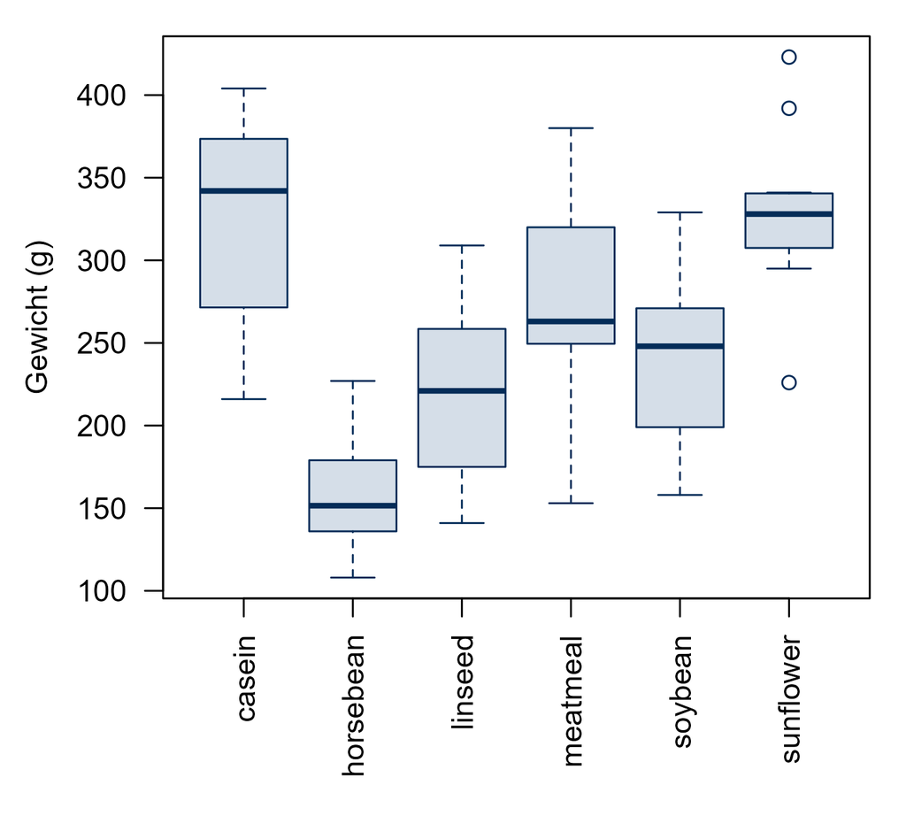

## Semesterplan

| Nr. | Datum | Thema | Abgabe |  |  |
| --- | --- | --- | --- | --- | --- |
| 1 | 22.10. | Einführung und Organisatorisches |  | A. Lehrende |  |
| 2 | 29.10. | Thema 2 | 04.11. |  |  |
| 3 | 05.11. | Thema 3 |  |  |  |
| entfällt (Lektürewoche) |  |  |  |  |  |
| 4 | 19.11. | Thema 4 | 25.11. |  |  |
| 5 | 26.11. | Thema 5 |  |  | B. Lehrende |
| 6 | 03.12. | Thema 6 | 09.12. |  |  |

# Gestaltungselemente

## Schrittweise Einblendungen

Text vor der ersten Pause ist sofort zu sehen.

### Nach einer Pause

- `. . .` auf einer eigenen Zeile: Alles Folgende erscheint erst beim nächsten Klick
- `::: incremental` zeigt eine Liste Punkt für Punkt
- `::: fragment` lässt einen ganzen Block erscheinen
- Im Handout (PDF) erscheinen alle Inhalte sofort

## Kästen, Farben und Text

**Merke:** `::: kasten` hebt einen Block hervor, z. B. die Antwort auf eine Fragestellung.

Grün, Rot, Akzent und Grau färben Text ein.

Fragestellungen stehen kursiv: Unterscheidet sich der Verbrauch je nach Getriebe?

Box ⟶ Box in Leitfarbe

`.anm` setzt eine kleine Anmerkung, z. B. unter Code. `::: klein` verkleinert ganze Blöcke.

## Formeln

Der Mittelwert $\bar{x}$ fasst die Werte $x_1, \dots, x_n$ zusammen:

$$\bar{x} = \frac{1}{n} \sum_{i=1}^{n} x_i$$

### t-Test für eine Stichprobe

$$t = \frac{\bar{x} - \mu_0}{s / \sqrt{n}}$$

Unter $H_0$ folgt $t$ einer *t*-Verteilung mit $n - 1$ Freiheitsgraden.

## Symbole

- `## Titel {.achtung}` setzt das Warndreieck an den Folientitel
- Im Text: mit `[]{.symbol-achtung}` und mit `[]{.symbol-ki}`

### Zusatzaufgabe mit KI

- `{.ki}` hängt den KI-Stern an eine Überschrift oder an Text

## Nur im Vortrag

- `{.no-handout}` an einem Bild, Block oder einer Spalte blendet es im Handout aus, der Platz bleibt frei
- Die rechte Spalte ist nur im Vortrag zu sehen
- Typisch: Memes, Umfragen, organisatorische Hinweise

**Kurze Pause:** Weiter geht es in zehn Minuten.

## Diese Folie fehlt im Handout

- `## Titel {.no-handout}` entfernt die ganze Folie aus dem Handout
- Die Foliennummern im PDF bleiben wie im Vortrag, die Nummer dieser Folie wird dort übersprungen

# R-Code und Output

Code wird standardmäßig angezeigt

## Code und Output

### Daten vorbereiten

```r
daten <- mtcars
daten$getriebe <- factor(daten$am, levels = c(0, 1),
                         labels = c("Automatik", "Schaltung"))
```

`#| eval: false`: Der Code wird nur gezeigt, nicht ausgeführt.

### Mittelwerte

```r
aggregate(mpg ~ getriebe, data = daten, FUN = mean)
```

```
   getriebe      mpg
1 Automatik 17.14737
2 Schaltung 24.39231
```

## Grafiken mit ggplot2

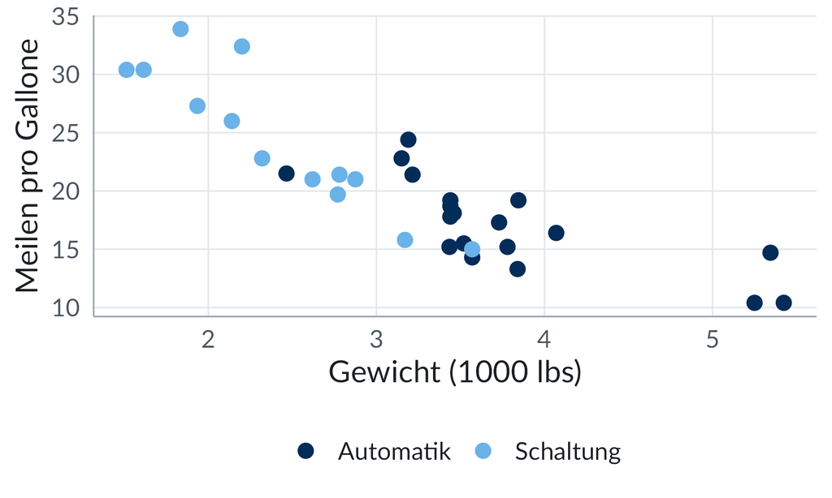

```r
ggplot(daten, aes(x = wt, y = mpg, colour = getriebe)) +
  geom_point(size = 3) +
  labs(x = "Gewicht (1000 lbs)", y = "Meilen pro Gallone", colour = NULL)
```

`source("_resources/R/rptu.R")` im Setup-Chunk setzt Theme, Farben und Schrift.

## Markierungen im Output

Hängt der Verbrauch (Meilen pro Gallone) vom Gewicht des Autos ab?

```r
modell <- lm(mpg ~ wt, data = mtcars)
coef(summary(modell))
```

```
             Estimate Std. Error   t value     Pr(>|t|)
(Intercept) 37.285126   1.877627 19.857575 8.241799e-19
wt          -5.344472   0.559101 -9.559044 1.293959e-10
```

- 1 **Steigung:** pro 1000 lbs mehr Gewicht 5.34 Meilen weniger pro Gallone
- 2 **t-Wert** der Steigung
- 3 *p*-Wert: *p* < .001, der Zusammenhang ist signifikant

## Farben selbst wählen

```r
coef(modell)
```

```
(Intercept)          wt
  37.285126   -5.344472
```

- 1 **Achsenabschnitt:** erwartete Meilen pro Gallone bei Gewicht 0 (nur rechnerisch)
- 2 **Steigung:** wie auf der vorigen Folie, jetzt in der Farbe der Rolle `steigung`

`farben="achsenabschnitt steigung"` nutzt die Rollen aus `markierung-rollen:` im Kopf, hier mit dem eigenen Farbwert `"#3470A8"`. Statt Rollen gehen auch Farbnamen wie `gruen`.

## Übung 1

**Datensatz:** *chickwts* (in R enthalten)  
**Fragestellung:** Unterscheidet sich das Gewicht der Küken je nach Futter?

### Aufgaben

1. Verschaffen Sie sich einen Überblick über den Datensatz.
2. Berechnen Sie eine einfaktorielle Varianzanalyse.

### Zusatzaufgabe

- Lassen Sie sich von einer KI R-Code für eine passende Grafik erzeugen.

## Output Übung 1

```
Analysis of Variance Table

Response: weight
          Df Sum Sq Mean Sq F value    Pr(>F)
feed       5 231129   46226  15.365 5.936e-10 ***
Residuals 65 195556    3009
---
Signif. codes:  0 '***' 0.001 '**' 0.01 '*' 0.05 '.' 0.1 ' ' 1
```

## Lösung Übung 1

```
Analysis of Variance Table

Response: weight
          Df Sum Sq Mean Sq F value    Pr(>F)
feed       5 231129   46226  15.365 5.936e-10 ***
Residuals 65 195556    3009
---
Signif. codes:  0 '***' 0.001 '**' 0.01 '*' 0.05 '.' 0.1 ' ' 1
```

- 1 **F-Wert**
- 2 *p*-Wert: *p* < .001

**Unterscheidet sich das Gewicht der Küken je nach Futter?** Ja, *F*(5, 65) = 15.37, *p* < .001.